# Scouting de WRs para o Fantasy com R e nflscrapR

Thomas Martins

03/08/2019

A temporada 2019 da NFL já vai começar, e com ela também as ligas de Fantasy. Na véspera do início da temporada regular é quando acotecem a maioria dos Drafts, então já é hora de ir pensando em quais jogadores escolher para o resto da temporada.

Bem, imagino que cada jogador de Fantasy tenha a sua maneira de fazer o *scouting*, isto é, analisar e comparar jogadores de forma a fazer as melhores escolhas no dia do Draft. Meu objetivo com este texto é introduzir uma nova, com o auxílio da programação em linguagem R (uma das mais utilizadas em ciência de dados) e de uma base de dados com jogadas da temporada passada da NFL. Aqui irei focar na posição de *wide receivers*, uma das que mais pontuam no Fantasy.

### Programação em R e dados do nflscrapR

Nas áreas de estatística e ciência de dados, a [linguagem de programação R](https://oestatistico.com.br/por-que-devemos-aprender-a-programar-em-r/) é uma das mais populares, tendo seu uso difundido tanto entre pesquisadores como também profissionais do mercado. Não é um bicho de sete cabeças, é simples de aprender, mesmo para quem não tem *background* de computação, TI e afins. A criação de bibliotecas como o [dplyr](http://leg.ufpr.br/~walmes/cursoR/data-vis/slides/05-dplyr.pdf) e [ggplot2](https://www.curso-r.com/material/ggplot/), por exemplo, potencializaram ainda mais os poderes desta ferramenta.

O [trabalho](https://arxiv.org/abs/1802.00998) de Ron Yurko, Max Horowitz e Sam Ventura, pesquisadores da Universidade Carnegie Mellon, nos Estados Unidos, levou à criação de outra biblioteca para o R chamada [*nflscrapR*](https://github.com/maksimhorowitz/nflscrapR), que possibilita a raspagem de dados *play-by-play* de todas as temporadas da NFL começando em 2009. Nestas bases também estão inclusos, para cada jogada, o resultado de um modelo estatístico criado pelos autores denominado [*Expected Points Added* (EPA)](https://www.cmusportsanalytics.com/nfl-expected-points-nflscrapr-part-1-introduction-expected-points/), que não será o foco deste texto porém tenho planos de falar sobre ele no futuro.

### Scouting de WRs para o Fantasy: estatísticas úteis

Gostaria de deixar claro que não sou nenhum especialista de Fantasy. Não conheço cada detalhe das regras, só sei o básico mesmo. Portanto esta foi a parte em que mais aprendi durante a elaboração deste texto. Não me lembro em detalhes as regras para o cálculo da pontuação, mas pelo que eu me lembre ela depende de jardas conquistadas, touchdowns marcados e, nas ligas PPR, recepções realizadas. Tem [alguns](https://diarionfl.com/2017/08/24/aprenda-a-jogar-fantasy-football-4/) bons [tutoriais](https://ligados32.lance.com.br/guia-de-fantasy/) em português

Decidi focar na posição de WR aqui pois, junto com *running backs*, são as posições que mais pontuam no Fantasy. Só que para pontuar no jogo virtual, os jogadores também precisam ter um bom desempenho nos campos da NFL. No caso específico de WRs e RBs, a produção está muito atrelada ao *quarterback* do time e ao sistema ofensivo como um todo.

Algumas estatísticas mais comuns, como a porcentagem de passes completos, podem nos trazer informação valiosa sobre os *wide receivers*. No entanto, alguns sites especializados de Fantasy, como o PFF, também notam outros fatores que podem ser indicativos do desempenho de um WR no Fantasy. Entre alguns desses estão a **profundidade média do WR nos alvos** (conhecido em inglês pela sigla aDOT, *average depth of target*), indicando se os passes recebidos pelo jogador são mais curtos ou longos (e passes longos resultam em mais pontos no Fantasy), **jardas pós-contato**, fator que independe do *quarterback* e aumenta a produção ofensiva do WR, e a **porcentagem de alvos daquele WR entre todos os passes do time**, também um indicativo de maior número de jardas para um WR, dado uma mesma porcentagem de passes completos.

### Explorando a base

Recentemente no Twitter, o analista Ben Baldwin fez um tutorial sobre como acessar e explorar as bases do nflscrapR para qualquer um que pudesse ver. O tutorial foi de grande ajuda para mim, inclusive na elaboração deste artigo. Irei deixar o [link](https://gist.github.com/guga31bb/5634562c5a2a7b1e9961ac9b6c568701) para quem mais possa se interessar

Antes de começar nossa análise, vamos carregar todas as bibliotecas que iremos precisar

```r
install.packages("tidyverse")
install.packages("dplyr")
install.packages("na.tools")
install.packages("ggplot2")
install.packages("ggridges")
install.packages("teamcolors")
install.packages("plotly")
```

```r
library(tidyverse)
library(dplyr)
library(na.tools)
library(ggplot2)
library(ggridges)
library(teamcolors)
library(plotly)
```

É possível instalar a biblioteca do nflscrapR e usar seus comandos para raspar os dados, porém é mais fácil e rápido baixar direto do site dos autores, da seguinte forma:

```r
pbp <- read_csv(url("https://github.com/ryurko/nflscrapR-data/raw/master/play_by_play_data/regular_season/reg_pbp_2018.csv"))
```

Os dados são da temporada de 2018, porém é possível pegar de outros anos trocando o número ali no fim do código.

A biblioteca dplyr irá facilitar tremendamente nosso trabalho. Ela faz parte do [tidyverse](http://www.estatisticacomr.uff.br/?page_id=741), um conjunto de bibliotecas de R para ciência de dados. Para quem, assim como eu, é acostumado a programar em Python, ela é similar à biblioteca pandas deste último, e o operador *pipe* do R, representado por %>%, é equivalente aos métodos de classes do Python, desta forma “df %>% head” no tidyverse é equivalente a “df.head()” no pandas

Vamos então usar este comando “head”, também filtrando as colunas com o “select”, para ver as primeiras linhas da base do nflscrapR:

```r
pbp %>% select(posteam,defteam,time,yrdln,desc,play_type) %>% head
```

```
## # A tibble: 6 x 6
##   posteam defteam time   yrdln desc                               play_type
##   <chr>   <chr>   <time> <chr> <chr>                              <chr>
## 1 ATL     PHI     15:00  PHI ~ J.Elliott kicks 65 yards from PHI~ kickoff
## 2 ATL     PHI     15:00  ATL ~ (15:00) PENALTY on ATL-L.Paulsen,~ no_play
## 3 ATL     PHI     15:00  ATL ~ (15:00) M.Ryan pass short right t~ pass
## 4 ATL     PHI     14:22  ATL ~ (14:22) J.Jones left end pushed o~ run
## 5 ATL     PHI     13:46  ATL ~ (13:46) D.Freeman right end to PH~ run
## 6 ATL     PHI     13:10  PHI ~ (13:10) M.Ryan pass incomplete sh~ pass
```

A base contém dados de todas as jogadas de todos os jogos da temporada regular de 2018. Como queremos analisar *wide receivers* (e também *tight ends*), podemos filtrar as jogadas para ficarmos apenas com as de passe, neste primeiro momento passes completos. Fazemos o seguinte:

```r
passes <- pbp %>% filter(play_type == "pass" & incomplete_pass == 0 & complete_pass == 1)

### Usando o R base ao invés do dplyr/tidyverse ficaria da seguinte forma:
###passes <- subset(pbp, play_type == "pass" & incomplete_pass == 0)

passes %>% select(posteam,defteam,time,yrdln,desc,play_type) %>% head
```

```
## # A tibble: 6 x 6
##   posteam defteam time   yrdln desc                               play_type
##   <chr>   <chr>   <time> <chr> <chr>                              <chr>
## 1 ATL     PHI     15:00  ATL ~ (15:00) M.Ryan pass short right t~ pass
## 2 ATL     PHI     13:01  PHI ~ (13:01) (Shotgun) M.Ryan pass dee~ pass
## 3 PHI     ATL     10:10  PHI 4 (10:10) (Shotgun) N.Foles pass sh~ pass
## 4 ATL     PHI     07:01  PHI ~ (7:01) M.Ryan pass short left to ~ pass
## 5 ATL     PHI     06:19  PHI ~ (6:19) M.Ryan pass short left to ~ pass
## 6 PHI     ATL     03:46  PHI ~ (3:46) (Shotgun) N.Foles pass sho~ pass
```

Vale notar que excluímos da nossa análise as conversões de dois pontos após touchdowns.

A biblioteca ggplot2 nos permite fazer gráficos muito mais bonitos que os do R base. Com o ggridges, podemos fazer *ridgeline plots*, um tipo de gráfico bem útil. Vamos tentar fazer um para ver a distribuição da profundidade dos alvos nos passes completos dos recebedores do Los Angeles Rams em 2018

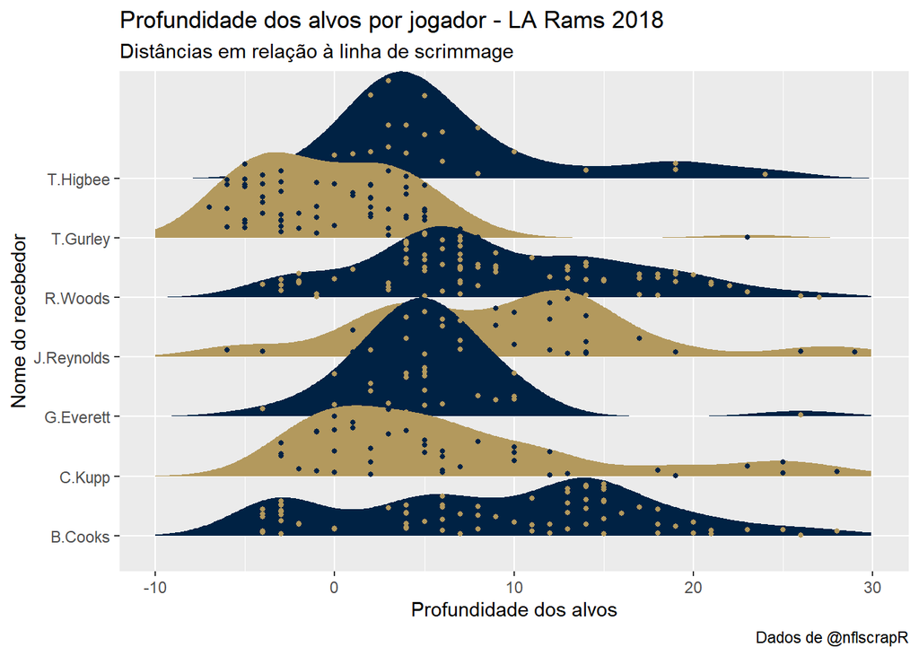

```r
data(teamcolors)

rams_rec_count <- passes %>% filter(posteam=="LA") %>% count(receiver_player_name) %>% filter(n>5 & !is.na(receiver_player_name))

ggplot(passes %>% filter(posteam=="LA" & !is.na(receiver_player_name) & receiver_player_name %in% rams_rec_count$receiver_player_name), aes(x=air_yards, y=receiver_player_name,fill=receiver_player_name,color=receiver_player_name)) + geom_density_ridges(jittered_points = TRUE, point_size=1,scale=2) + labs(x = "Profundidade dos alvos", y = "Nome do recebedor", title = "Profundidade dos alvos por jogador - LA Rams 2018", subtitle="Distâncias em relação à linha de scrimmage", caption = "Dados de @nflscrapR") + scale_x_continuous(limits = c(-10,30)) + scale_fill_cyclical(values = teamcolors %>% filter(name == "Los Angeles Rams") %>% select(primary,secondary)) +
scale_color_cyclical(values = teamcolors %>% filter(name == "Los Angeles Rams") %>% select(secondary,primary))
```

Constatamos que o *running back* T. Gurley recebe a maioria de seus passes próximo à linha de scrimmage, *tight ends* (T. Higbee e G. Everett) recebendo bastante passes curtos (assim como o WR C. Kupp, que costuma alinhar no slot) e os *wide receivers* R.Woods, B. Cooks e J. Reynolds recebendo passes, em média, mais profundos.

Agora vamos contar a quantidade de passes completos por jogador:

```r
receiver_count <- passes %>% group_by(receiver_player_name,posteam) %>% count(receiver_player_name) %>% arrange(desc(n))


### filtrando os com mais de 80 passes completos
rec_count_80 <- receiver_count %>% filter(n>79 & !is.na(receiver_player_name))
rec_count_80
```

```
## # A tibble: 21 x 3
## # Groups:   receiver_player_name, posteam [21]
##    receiver_player_name posteam     n
##    <chr>                <chr>   <int>
##  1 M.Thomas             NO        125
##  2 Z.Ertz               PHI       116
##  3 D.Hopkins            HOU       115
##  4 A.Thielen            MIN       113
##  5 J.Jones              ATL       113
##  6 D.Adams              GB        111
##  7 J.Smith-Schuster     PIT       111
##  8 C.McCaffrey          CAR       107
##  9 A.Brown              PIT       104
## 10 T.Kelce              KC        103
## # ... with 11 more rows
```

Fazendo mais um gráfico daqueles, agora para estes jogadores

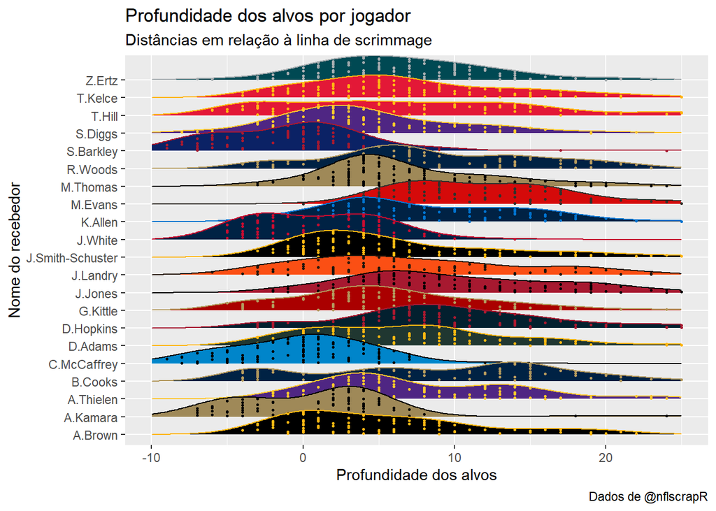

```r
teamcolors_nfl <- teamcolors %>% filter(league == "nfl") %>% mutate(teamID = c("ARI", "ATL", "BAL", "BUF", "CAR", "CHI", "CIN", "CLE", "DAL", "DEN", "DET", "GB", "HOU", "IND", "JAX", "KC", "LAC", "LA", "MIA", "MIN", "NE", "NO", "NYG", "NYJ" , "OAK", "PHI", "PIT", "SF", "SEA", "TB", "TEN", "WAS"))

passes_color <- passes %>% left_join(teamcolors_nfl,by=c("posteam" = "teamID"), copy = TRUE) %>% filter(!(posteam == "NO" & receiver_player_name == "T.Hill")) ### sorry, Taysom

ggplot(subset(passes_color,receiver_player_name %in% rec_count_80$receiver_player_name), aes(x=air_yards, y=receiver_player_name,fill=factor(name),color=factor(name))) + geom_density_ridges(jittered_points = TRUE, point_size=0.5) + labs(x = "Profundidade dos alvos", y = "Nome do recebedor", title = "Profundidade dos alvos por jogador", subtitle="Distâncias em relação à linha de scrimmage", caption = "Dados de @nflscrapR") + scale_x_continuous(limits = c(-10,25)) + scale_fill_teams(name="name") + scale_color_teams(name="name",which=2) + theme(legend.position = "none")
```

É importante visualizar o formato da distribuição, mas podemos também fazer um diagrama de dispersão com as médias, tanto para profundidade do alvo como para jardas pós-contato. Novamente utilizamos o dplyr:

```r
avg_depth <- passes %>% group_by(receiver_player_name,posteam) %>% summarize(mean_depth=mean(air_yards), mean_yac=mean(yards_after_catch), comp_passes=n()) %>% arrange(desc(comp_passes)) %>% filter(comp_passes > 29)

### apenas jogadores com mais de 30 passes completos
avg_depth
```

```
## # A tibble: 141 x 5
## # Groups:   receiver_player_name [139]
##    receiver_player_name posteam mean_depth mean_yac comp_passes
##    <chr>                <chr>        <dbl>    <dbl>       <int>
##  1 M.Thomas             NO           7.13      4.11         125
##  2 Z.Ertz               PHI          6.98      3.04         116
##  3 D.Hopkins            HOU         10.3       3.37         115
##  4 A.Thielen            MIN          8.47      3.68         113
##  5 J.Jones              ATL         10.9       3.96         113
##  6 D.Adams              GB           8.21      4.28         111
##  7 J.Smith-Schuster     PIT          7.01      5.45         111
##  8 C.McCaffrey          CAR          0.150     7.95         107
##  9 A.Brown              PIT          7.81      4.66         104
## 10 T.Kelce              KC           7.45      5.52         103
## # ... with 131 more rows
```

```r
avg_depth <- avg_depth %>% mutate(text = paste("Nome: ", receiver_player_name, " (", posteam,")", "\nPasses Completos: ", comp_passes, "\nProfundidade média (aDOT): ", sprintf("%0.2f",mean_depth), "\nJardas pós contato (média)", sprintf("%0.2f",mean_yac)))

color_palette <- teamcolors_nfl %>% select(name,teamID,primary,secondary)

avg_depth_color <- avg_depth %>% left_join(color_palette,by=c("posteam" = "teamID"), copy = TRUE)

bubble <- ggplot(avg_depth_color, aes(x=mean_depth, y=mean_yac, size = comp_passes, color=factor(name), text=text)) + geom_point(alpha=0.7) + scale_color_teams(name="name") + theme(legend.position="none") + labs(x = "Profundidade média dos alvos (aDOT)", y = "Média de jardas pós contato", title = "Profundidade média (aDOT) e jardas pós-contato", subtitle="Tamanho da bolinha = nº de passes completos", caption = "Dados de @nflscrapR")

ggplotly(bubble, tooltip="text")
```

[interactive chart not shown]

Agora que já vimos a profundidade média e jardas pós-contato, podemos analisar a porcentagem de alvos. Para isto, pegamos todas as jogadas de passe novamente

```r
passes_team <- subset(pbp, complete_pass == 1 | incomplete_pass == 1)

target_pct <- passes_team %>% group_by(posteam,receiver_player_name) %>% summarize(targets=n()) %>% filter(!is.na(receiver_player_name) & targets>25)

target_team <- passes_team %>% group_by(posteam) %>% summarize(targets=n())

target_pct <- merge(x=target_pct,y=target_team,by="posteam")

target_pct <- target_pct %>% mutate(target_pct = targets.x/targets.y)

target_pct <- target_pct %>% rename(targets = targets.x, team_targets = targets.y) %>% arrange(desc(target_pct)) #%>% mutate(target_pct = sprintf("%0.2f", target_pct))

target_pct %>% head
```

```
##   posteam receiver_player_name targets team_targets target_pct
## 1     HOU            D.Hopkins     160          497  0.3219316
## 2      NO             M.Thomas     146          512  0.2851562
## 3     ATL              J.Jones     167          610  0.2737705
## 4     LAC              K.Allen     134          500  0.2680000
## 5      GB              D.Adams     169          636  0.2657233
## 6     CLE             J.Landry     147          557  0.2639138
```

A coluna target_pct é a porcentagem dos passes do time em que aquele jogador foi alvo. Por exemplo, DeAndre Hopkins foi alvo de 32,2% dos passes do Houston Texans em 2018. Podemos tentar visualizar em um gráfico simples:

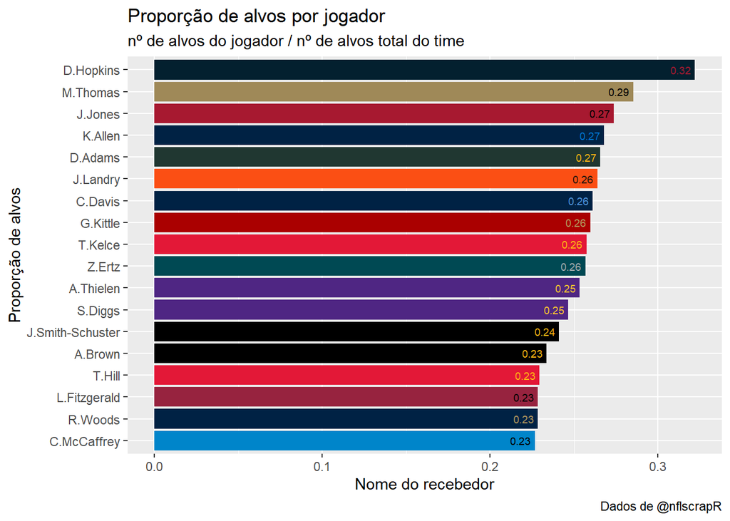

```r
target_pct_color <- target_pct %>% left_join(color_palette,by=c("posteam" = "teamID"), copy = TRUE)

ggplot(subset(target_pct_color,target_pct>0.22),aes(x=reorder(receiver_player_name,target_pct),y=target_pct,fill=factor(name))) + geom_bar(stat="identity") + coord_flip() + labs(x = "Proporção de alvos", y = "Nome do recebedor", title = "Proporção de alvos por jogador", subtitle="nº de alvos do jogador / nº de alvos total do time", caption = "Dados de @nflscrapR") + scale_fill_teams(name="name") + theme(legend.position = "none") + geom_text(aes(label=sprintf("%0.2f",target_pct),color=factor(name)), size=2.5,hjust = 1.2) + scale_color_teams(name="name",which=2)
```

Bem, já deu um belo trabalho aqui. Esta foi a minha primeira vez explorando os dados do nflscrapR, e deu pra ter uma bela noção do potencial da ferramenta. Pretendo fazer mais análises no futuro, a temporada já vai começar e assim as perguntas a serem respondidas irão surgindo.